# Variable contingency and affiliation prediction

Clemens Schmid

2017-10-19

This Vignette shows a workflow for archaeologists workig on burial sites. Starting point is a data.frame with burials (objects) and their classified attributes (grave goods, orientation, size, sex etc.). An example dataset with 50 fictional burials and 18 stereotypical attributes is provided in `data/bs1`. Here’s an extract of bs1:

```
##    adze_1 adze_2 pottery_1 pottery_2 pottery_3 pottery_4 goldring goldbead
## 1       9      5         0         0         0         0        0       10
## 2       0      0         8         1         0         0        0       30
## 3       3      0         0         0         0         0        0        0
## 4       4      0         8         0         0         0        0        2
## 5       0      5         0         2         0         0        0        9
## 6       4      0         5         0         0         0        0        0
## 7       0      0         0         0         0         0        0        0
## 8       3      0         5         0         0         0        0        0
## 9       0      0         0         3         0         0        0        5
## 10      9      4         7         0         0         0        0        3
```

For bivariate analysis it’s useful to use categorized data. In the context of burialsites the simple information wether a grave good is present or absent in a certain grave is often already sufficient. To reduce our dataset to this information the function `booleanize()` can be applied. Empty graves and attributes that never appeare can be removed with `delempty()`.

```r
bs <- quantAAR::booleanize(bs1)
bs <- quantAAR::delempty(bs)
bs[1:10,9:16]
```

```
##    adze_1 adze_2 pottery_1 pottery_2 pottery_3 pottery_4 goldring goldbead
## 1       1      1         0         0         0         0        0        1
## 2       0      0         1         1         0         0        0        1
## 3       1      0         0         0         0         0        0        0
## 4       1      0         1         0         0         0        0        1
## 5       0      1         0         1         0         0        0        1
## 6       1      0         1         0         0         0        0        0
## 7       0      0         0         0         0         0        0        0
## 8       1      0         1         0         0         0        0        0
## 9       0      0         0         1         0         0        0        1
## 10      1      1         1         0         0         0        0        1
```

Let’s look at the appearences of the individual grave goods with `presencecount()`. While most goods are frequent, *pottery_4* is quite rare - too rare to be meaningfully analyzed with chi square statistics.

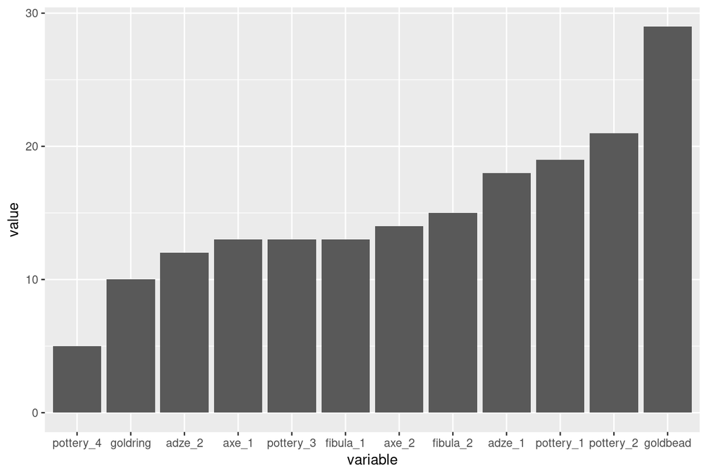

```r
presencematerial <- quantAAR::presencecount(bs[,7:18], dim = 1)

presence.m <- reshape2::melt(presencematerial)
ggplot(presence.m,
       aes(x = variable,
           y = value)) +
  geom_bar(stat = "identity")
```

With `delrc()` we can delete every grave good that appeares less than ten times. As a consequence *pottery_4* is removed.

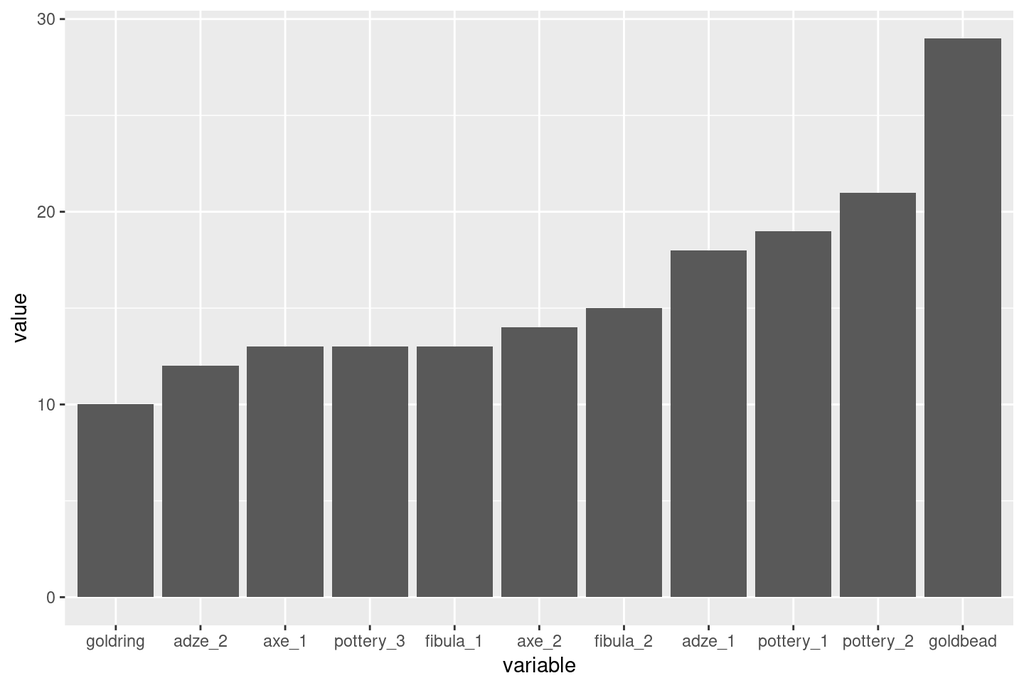

```r
bsred <- bs[,7:18]
bsred <- quantAAR::delrc(bsred, climit = 10)

presencematerial <- quantAAR::presencecount(bsred, dim = 1)
presence.m <- reshape2::melt(presencematerial)
ggplot(presence.m,
       aes(x = variable,
           y = value)) +
  geom_bar(stat = "identity")
```

Now we can calculate the bivariate relations of all attributes with the function `corrmat()`. `corrmat()` offers different correlation values. In this case we use the testdecision of the chi square test on a significance level of 2% and the phi coefficient. `rmnegcorr()` is used to remove significant but negative relationships.

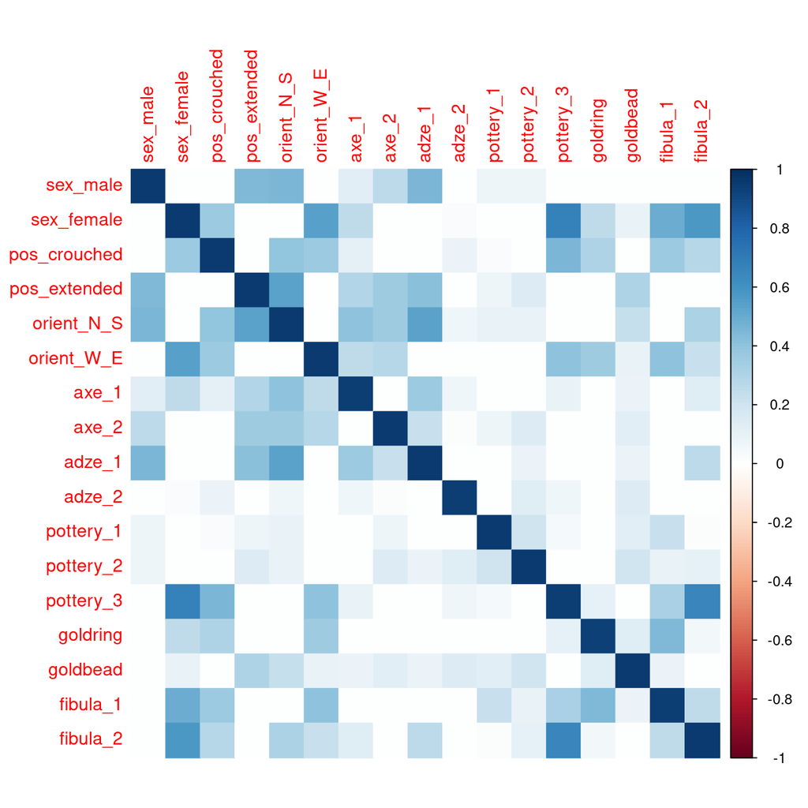

```r
bsprep <- data.frame(bs[,1:6], bsred)
corrtablechi2test <- quantAAR::corrmat(bsprep, method = "chi2", dim = 1, chi2limit = 0.02)
corrtablephi <- quantAAR::corrmat(bsprep, method = "phi", dim = 1)
mastercorr <- quantAAR::rmnegcorr(corrtablephi, bsprep, niv = 0.1, dim = 1)

col2 <- grDevices::colorRampPalette(c("white","white", "chartreuse4"))
corrplot::corrplot(
  t(mastercorr),
  method = c("color")
  )
```

`reltable()` creates a list of the significant relationships within the correlation table. We choose the phi coefficient to be the first correlation value and the chi square test decision to be the second.

```r
signicorr <- quantAAR::reltable(mastercorr, corrtablechi2test)
signicorr <- dplyr::filter(signicorr, corrvalue2 == TRUE)

signicorr
```

```
##    indexvar1 indexvar2 corrvalue     namevar1     namevar2 corrvalue2
## 1         13         2 0.6794300    pottery_3   sex_female          1
## 2         17        13 0.6566920     fibula_2    pottery_3          1
## 3         17         2 0.5790660     fibula_2   sex_female          1
## 4          6         2 0.5416667   orient_W_E   sex_female          1
## 5          5         4 0.5364523   orient_N_S pos_extended          1
## 6          9         5 0.5358259       adze_1   orient_N_S          1
## 7         16         2 0.4932848     fibula_1   sex_female          1
## 8          5         1 0.4583333   orient_N_S     sex_male          1
## 9         13         3 0.4578606    pottery_3 pos_crouched          1
## 10         9         1 0.4507742       adze_1     sex_male          1
## 11         4         1 0.4455282 pos_extended     sex_male          1
## 12        16        14 0.4445617     fibula_1     goldring          1
## 13         9         4 0.4138837       adze_1 pos_extended          1
## 14         7         5 0.4002122        axe_1   orient_N_S          1
## 15        13         6 0.4002122    pottery_3   orient_W_E          1
## 16        16         6 0.4002122     fibula_1   orient_W_E          1
## 17         5         3 0.3997431   orient_N_S pos_crouched          1
## 18         3         2 0.3657224 pos_crouched   sex_female          1
## 19         6         3 0.3657224   orient_W_E pos_crouched          1
## 20        16         3 0.3628688     fibula_1 pos_crouched          1
## 21         9         7 0.3628688       adze_1        axe_1          1
## 22        14         6 0.3572173     goldring   orient_W_E          1
## 23         8         4 0.3551587        axe_2 pos_extended          1
## 24         8         5 0.3546041        axe_2   orient_N_S          1
```

The network of bivariate relationships can be plotted as a graph with the igraph-package. The male and the female clusters are clearly distinguishable.

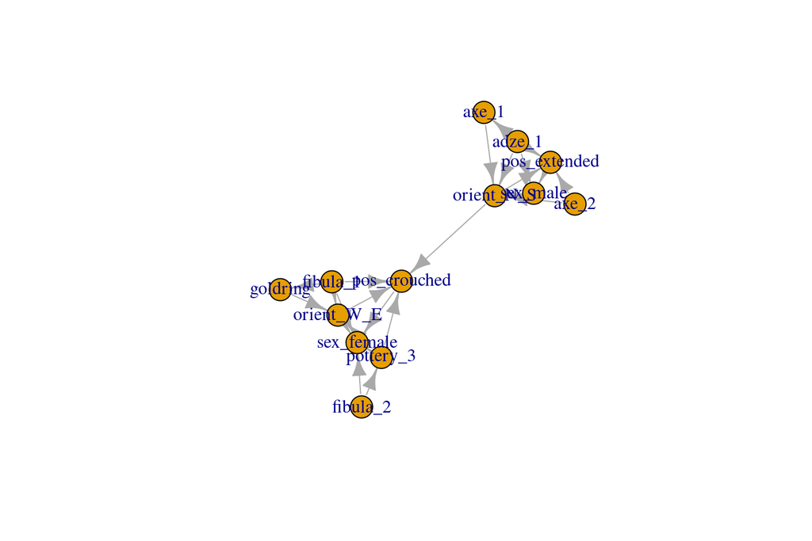

```r
signicorrmod <- data.frame(
  from = signicorr$namevar1,
  to = signicorr$namevar2,
  weight = signicorr$corrvalue)

graphbasis <- igraph::graph.data.frame(signicorrmod, directed = TRUE)
igraph::plot.igraph(graphbasis)
```

Within *signicorr* it’s easy to search for the directly to an individual attribute linked attributes (level 1 relations).

```r
mvar <- c("sex_male", "sex_female")

mvar1male <- dplyr::filter(
  signicorr,
  namevar1 == mvar[1] |
    namevar2 == mvar[1]
)

mvar1male
```

```
##   indexvar1 indexvar2 corrvalue     namevar1 namevar2 corrvalue2
## 1         5         1 0.4583333   orient_N_S sex_male          1
## 2         9         1 0.4507742       adze_1 sex_male          1
## 3         4         1 0.4455282 pos_extended sex_male          1
```

```r
mvar1female <- dplyr::filter(
  signicorr,
  namevar1 == mvar[2] |
    namevar2 == mvar[2]
)


mvar1female
```

```
##   indexvar1 indexvar2 corrvalue     namevar1   namevar2 corrvalue2
## 1        13         2 0.6794300    pottery_3 sex_female          1
## 2        17         2 0.5790660     fibula_2 sex_female          1
## 3         6         2 0.5416667   orient_W_E sex_female          1
## 4        16         2 0.4932848     fibula_1 sex_female          1
## 5         3         2 0.3657224 pos_crouched sex_female          1
```

`predictvo()` uses the initial data.frame and *signicorr* to make a prediction about whether an object could contain a variable or not based on cross-references. Useful to determine for example the sex of buried individuals based on their grave goods when no anthropological determination is availbable.

```r
predictgen <- quantAAR::predictvo(bsprep, signicorr, mvar, level = 1)

sexprediction <- data.frame(
  m = predictgen[,1],
  w = predictgen[,3],
  statsex = NA,
  mtat = bsprep$sex_male,
  wtat = bsprep$sex_female,
  names = make.names(rownames(bsprep))
  )

for (i in 1:length(sexprediction[,1])){
  if (sexprediction$m[i] >= 1.5*sexprediction$w[i]){
    sexprediction$statsex[i] <- "m"
  } else if (sexprediction$w[i] >= 1.5*sexprediction$m[i]) {
    sexprediction$statsex[i] <- "w"
  } else {
    sexprediction$statsex[i] <- "uncertain"
  }
}

sexprediction
```

```
##            m         w   statsex mtat wtat names
## 1  1.0000000 0.0000000         m    1    0    X1
## 2  0.7500000 0.0000000         m    1    0    X2
## 3  0.5000000 0.0000000         m    1    0    X3
## 4  1.0000000 0.0000000         m    1    0    X4
## 5  0.5000000 0.1666667         m    1    0    X5
## 6  0.7500000 0.0000000         m    1    0    X6
## 7  0.5000000 0.0000000         m    1    0    X7
## 8  0.7500000 0.0000000         m    1    0    X8
## 9  0.7500000 0.0000000         m    1    0    X9
## 10 0.5000000 0.0000000         m    1    0   X10
## 11 1.0000000 0.0000000         m    1    0   X11
## 12 0.7500000 0.0000000         m    1    0   X12
## 13 0.5000000 0.0000000         m    1    0   X13
## 14 0.2500000 0.3333333 uncertain    1    0   X14
```

[output cut: 36 more lines]